# Demo - production economics concept and efficiency analysis.

Leveraing Agricultural Economic Research with R programming.

Christopher Llones

Last edited: 27 April 2022

# 1 Production economics concepts

## 1.1 Getting to know our data

Variables:

- `vCap` = cost of capital (including land)
- `vLab` = cost of labor (including remuneration of unpaid family labor)
- `vMat` = cost of intermediate materials (e.g., seedlings, fertilizer, etc.)
- `qOut` = quantity index of all outputs (apples and outputs)
- `pCap` price index of capital goods
- `pLab` price index of labor
- `pMat` price index of materials
- `pOut` price index of the aggregate output
- `adv` use of advisory service

```r
data("appleProdFr86", package = "micEcon")
dat <- appleProdFr86 %>% tibble()
dat %>% head(11)
```

| vCap | vLab | vMat | qApples | qOtherOut | qOut | pCap | pLab | pMat | pOut | adv |
| --- | --- | --- | --- | --- | --- | --- | --- | --- | --- | --- |
| 219183 | 323991 | 303155 | 1.391803 | 0.977272 | 1374063.5 | 2.607756 | 0.899811 | 8.893672 | 0.6603515 | 0 |
| 130572 | 187956 | 262017 | 0.863985 | 1.072186 | 1122979.2 | 3.292048 | 0.752518 | 6.418985 | 0.7155490 | 0 |
| 81301 | 134147 | 90592 | 3.316798 | 0.404785 | 2158518.1 | 2.194315 | 0.956237 | 3.740465 | 0.9367494 | 1 |
| 34007 | 105794 | 59833 | 0.438498 | 0.436311 | 507389.2 | 1.602476 | 1.268100 | 3.167017 | 0.5969751 | 1 |
| 38702 | 83717 | 104159 | 1.831252 | 0.014982 | 1070815.7 | 0.866295 | 0.938286 | 7.221408 | 0.8253856 | 1 |
| 122400 | 523842 | 577468 | 8.483304 | 0.425032 | 5166834.9 | 1.028355 | 0.956437 | 9.611689 | 1.3907442 | 1 |
| 89061 | 168140 | 343768 | 4.122254 | 3.295309 | 4302186.5 | 0.977214 | 1.001521 | 7.759671 | 1.3258699 | 1 |
| 92134 | 204859 | 126547 | 2.154374 | 1.058434 | 1863428.6 | 1.039822 | 0.915367 | 5.027134 | 0.6183344 | 0 |
| 65779 | 180598 | 190622 | 1.774644 | 2.602572 | 2538785.3 | 2.467659 | 1.017827 | 5.631467 | 1.9064262 | 0 |
| 94047 | 142240 | 82357 | 1.620606 | 0.445125 | 1198124.0 | 0.984915 | 0.640209 | 5.616957 | 0.4850528 | 0 |
| 51105 | 90317 | 120669 | 1.400039 | 1.013794 | 1400023.1 | 1.272267 | 0.961982 | 3.982859 | 0.7325346 | 1 |

## 1.2 Descriptive stats

```r
dat %>% skim()
```

Data summary

| Name | Piped data |
| --- | --- |
| Number of rows | 140 |
| Number of columns | 11 |
| _______________________ |  |
| Column type frequency: |  |
| numeric | 11 |
| ________________________ |  |
| Group variables | None |

**Variable type: numeric**

| skim_variable | n_missing | complete_rate | mean | sd | p0 | p25 | p50 | p75 | p100 | hist |
| --- | --- | --- | --- | --- | --- | --- | --- | --- | --- | --- |
| vCap | 0 | 1 | 102576.24 | 79992.28 | 8951.00 | 50856.00 | 84114.50 | 123251.50 | 452146.00 | ▇▃▁▁▁ |
| vLab | 0 | 1 | 237199.39 | 194867.78 | 79569.00 | 139379.00 | 175871.00 | 259314.25 | 1682201.00 | ▇▁▁▁▁ |
| vMat | 0 | 1 | 201250.06 | 208054.52 | 27781.00 | 81023.00 | 136291.50 | 224801.25 | 1523776.00 | ▇▁▁▁▁ |
| qApples | 0 | 1 | 3.07 | 5.46 | 0.00 | 0.43 | 1.37 | 3.26 | 37.98 | ▇▁▁▁▁ |
| qOtherOut | 0 | 1 | 1.50 | 1.32 | 0.01 | 0.56 | 1.07 | 1.92 | 5.96 | ▇▃▂▁▁ |
| qOut | 0 | 1 | 2649825.38 | 3300778.29 | 95391.44 | 998788.57 | 1773989.17 | 3152399.77 | 24210263.82 | ▇▁▁▁▁ |
| pCap | 0 | 1 | 1.30 | 0.79 | 0.17 | 0.77 | 1.11 | 1.62 | 4.48 | ▇▇▃▁▁ |
| pLab | 0 | 1 | 1.01 | 0.20 | 0.49 | 0.86 | 0.96 | 1.19 | 1.72 | ▁▇▅▂▁ |
| pMat | 0 | 1 | 6.77 | 2.64 | 2.70 | 4.87 | 6.25 | 8.37 | 15.71 | ▇▇▆▁▁ |
| pOut | 0 | 1 | 1.01 | 0.53 | 0.46 | 0.66 | 0.83 | 1.11 | 2.94 | ▇▂▁▁▁ |
| adv | 0 | 1 | 0.52 | 0.50 | 0.00 | 0.00 | 1.00 | 1.00 | 1.00 | ▇▁▁▁▇ |

## 1.3 Calculating input quantities

Our data set does not contain input quantities but prices and costs (volumes) of the inputs. Consider the formula below wherein $v_i$ is the volume of the ith input, $p_i$ is the price, and $x_i$ quantity.

$$v_i = x_i \times p_i$$

```r
dat <-
dat %>%
  mutate(qCap = vCap / pCap,
         qLab = vLab / pLab,
         qMat = vMat / pMat)
```

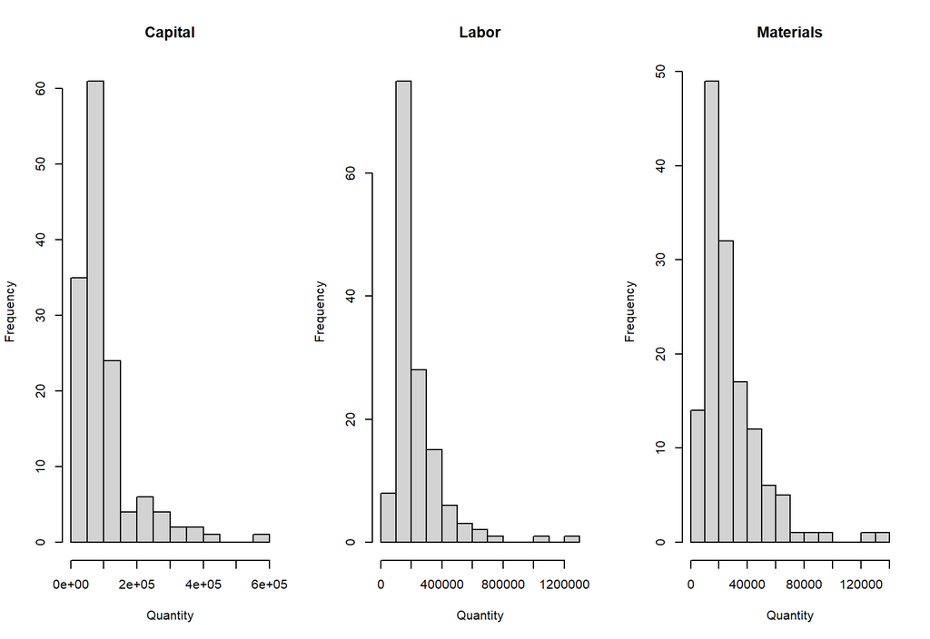

```r
par(mfrow = c(1, 3))
hist(dat$qCap, main = "Capital", xlab = "Quantity")
hist(dat$qLab, main = "Labor", xlab = "Quantity")
hist(dat$qMat, main = "Materials", xlab = "Quantity")
```

## 1.4 Calculating average products (AP)

Recall the average product as output quantity over input quantity.

$$AP = q / x_i$$

```r
dat <-
dat %>%
  mutate(apCap = qOut / qCap,
         apLab = qOut / qLab,
         apMat = qOut / qMat)
```

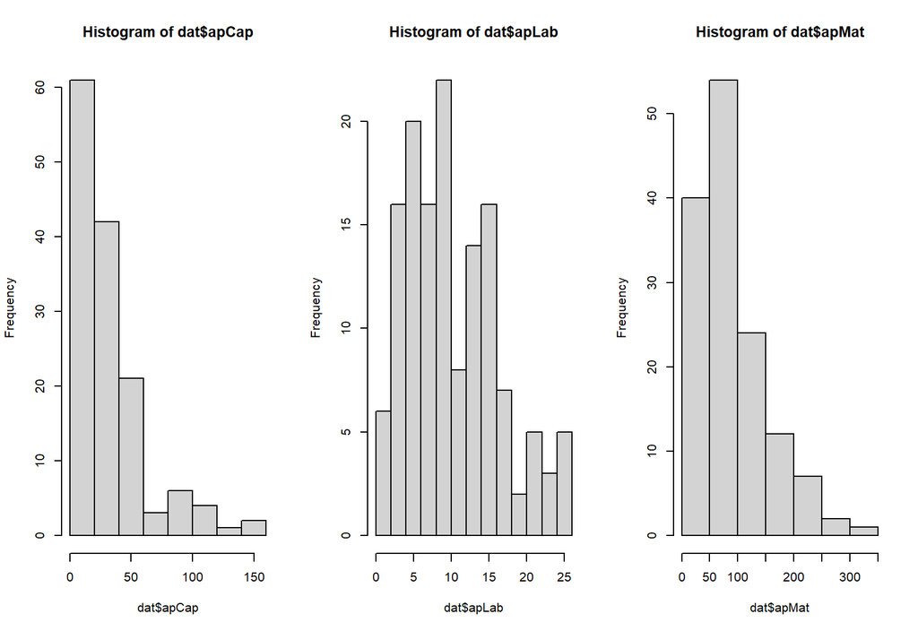

```r
par(mfrow = c(1, 3))
hist(dat$apCap)
hist(dat$apLab)
hist(dat$apMat)
```

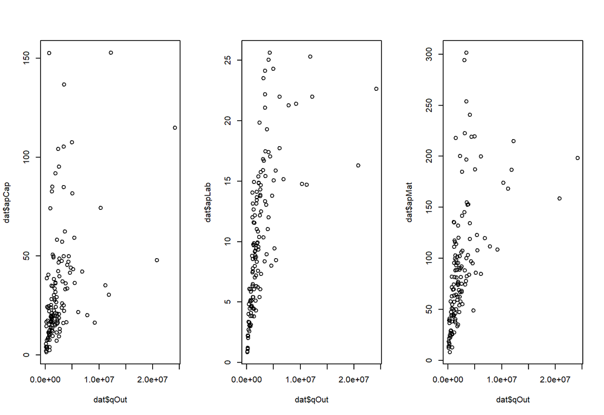

```r
par(mfrow = c(1, 3))
plot(dat$qOut, dat$apCap)
plot(dat$qOut, dat$apLab)
plot(dat$qOut, dat$apMat)
```

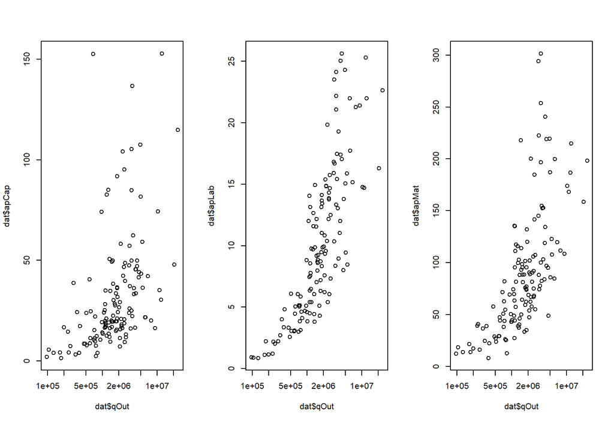

```r
par(mfrow = c(1, 3))
plot(dat$qOut, dat$apCap, log = "x")
plot(dat$qOut, dat$apLab, log = "x")
plot(dat$qOut, dat$apMat, log = "x")
```

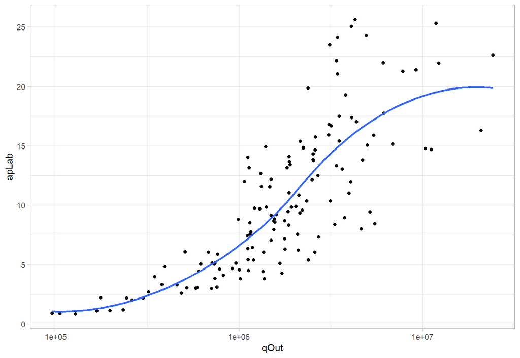

```r
dat %>%
  ggplot(aes(qOut, apLab)) +
  geom_point() +
  scale_x_log10() +
  geom_smooth(se = FALSE, span = 0.8) +
  theme_light()
```

# 2 Production efficiency analysis

## 2.1 Linear production function

$$y = \beta_0 + \Sigma^N_{i=1} \beta_i x_i$$
$$\operatorname{qOut} = \alpha + \beta_{1}(\operatorname{qCap}) + \beta_{2}(\operatorname{qLab}) + \beta_{3}(\operatorname{qMat}) + \epsilon$$

```r
prodLin <- lm( qOut ~ qCap + qLab + qMat, data = dat )
prodLin %>% summary()
```

```
Call:
lm(formula = qOut ~ qCap + qLab + qMat, data = dat)

Residuals:
     Min       1Q   Median       3Q      Max
-3888955  -773002    86119   769073  7091521

Coefficients:
              Estimate Std. Error t value Pr(>|t|)
(Intercept) -1.616e+06  2.318e+05  -6.972 1.23e-10 ***
qCap         1.788e+00  1.995e+00   0.896    0.372
qLab         1.183e+01  1.272e+00   9.300 3.15e-16 ***
qMat         4.667e+01  1.123e+01   4.154 5.74e-05 ***
---
Signif. codes:  0 '***' 0.001 '**' 0.01 '*' 0.05 '.' 0.1 ' ' 1

Residual standard error: 1541000 on 136 degrees of freedom
Multiple R-squared:  0.7868,    Adjusted R-squared:  0.7821
F-statistic: 167.3 on 3 and 136 DF,  p-value: < 2.2e-16
```

### 2.1.1 Marginal products and output elasticities

In a linear production function, the marginal product are equal to the coefficients of the corresponding quantities.

$$MP_i = \frac{\partial y}{\partial x_i} = \alpha_i$$
While the output elasticities (partial production elasticities) of our inputs are:

$$\epsilon_i = \frac{\partial y}{\partial x_i} = MP_i \times \frac{x_i}{y} = \frac{MP_i}{AP_i}$$

```r
dat$eCap <- coef(prodLin)["qCap"] * dat$qCap / dat$qOut
dat$eLab <- coef(prodLin)["qLab"] * dat$qLab / dat$qOut
dat$eMat <- coef(prodLin)["qMat"] * dat$qMat / dat$qOut

dat %>% select(starts_with("e")) %>% colMeans()
```

```
     eCap      eLab      eMat
0.1202721 2.0734793 0.8631936
```

## 2.2 Cobb-Douglas production function

A Cobb-Douglas production function with N inputs is defined as:

$$y = A \Pi_{i=1}^N x_i^{a_i}$$

This function can be linearized by taking the natural logarithm on both sides.

$$\ln y = \alpha_0 + \Sigma_{i=1}^N \alpha_i \ln x_i$$

$$\operatorname{log(qOut)} = \alpha + \beta_{1}(\operatorname{\log(qCap)}) + \beta_{2}(\operatorname{\log(qLab)}) + \beta_{3}(\operatorname{\log(qMat)}) + \epsilon$$

```r
prodCD <- lm(log(qOut) ~ log(qCap) + log(qLab) + log(qMat), data = dat)
summary(prodCD)
```

```
Call:
lm(formula = log(qOut) ~ log(qCap) + log(qLab) + log(qMat), data = dat)

Residuals:
     Min       1Q   Median       3Q      Max
-1.67239 -0.28024  0.00667  0.47834  1.30115

Coefficients:
            Estimate Std. Error t value Pr(>|t|)
(Intercept) -2.06377    1.31259  -1.572   0.1182
log(qCap)    0.16303    0.08721   1.869   0.0637 .
log(qLab)    0.67622    0.15430   4.383 2.33e-05 ***
log(qMat)    0.62720    0.12587   4.983 1.87e-06 ***
---
Signif. codes:  0 '***' 0.001 '**' 0.01 '*' 0.05 '.' 0.1 ' ' 1

Residual standard error: 0.656 on 136 degrees of freedom
Multiple R-squared:  0.5943,    Adjusted R-squared:  0.5854
F-statistic: 66.41 on 3 and 136 DF,  p-value: < 2.2e-16
```

### 2.2.1 Marginal products

$$MP_i = \frac{\partial y}{\partial x_i} = \frac{\partial \ln y}{\partial \ln x_i} \times \frac{y}{x_i}$$

```r
dat$mpCapCD <- coef(prodCD)["log(qCap)"] * dat$qOut / dat$qCap
dat$mpLabCD <- coef(prodCD)["log(qLab)"] * dat$qOut / dat$qLab
dat$mpMatCD <- coef(prodCD)["log(qMat)"] * dat$qOut / dat$qMat
```

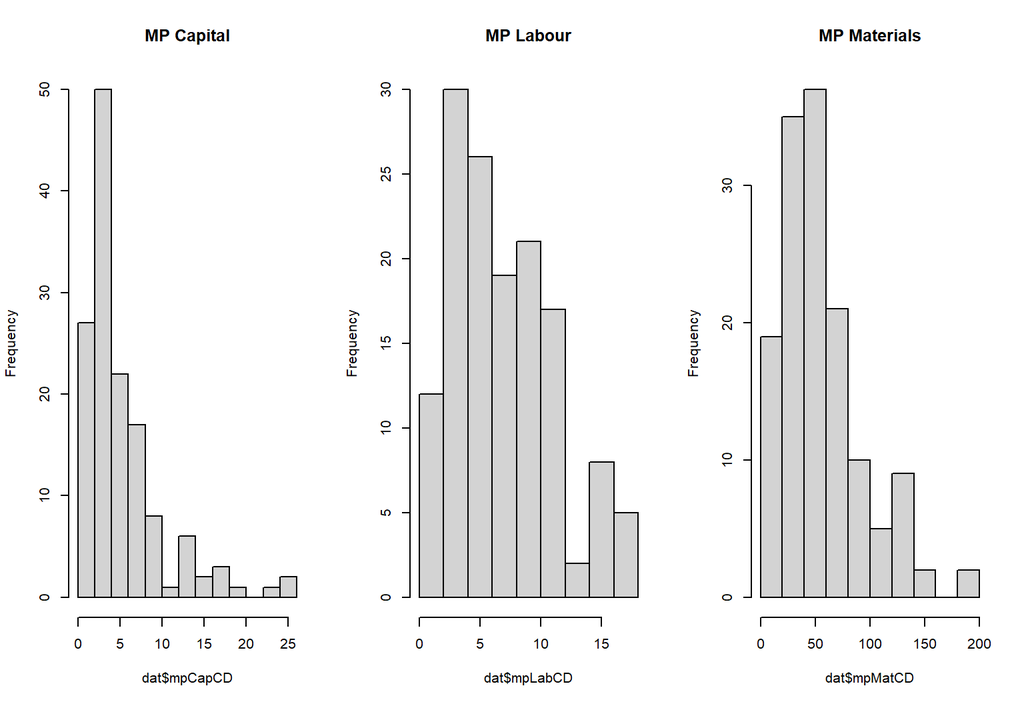

```r
par(mfrow = c(1, 3))
hist( dat$mpCapCD, main = "MP Capital")
hist( dat$mpLabCD, main = "MP Labour")
hist( dat$mpMatCD, main = "MP Materials")
```

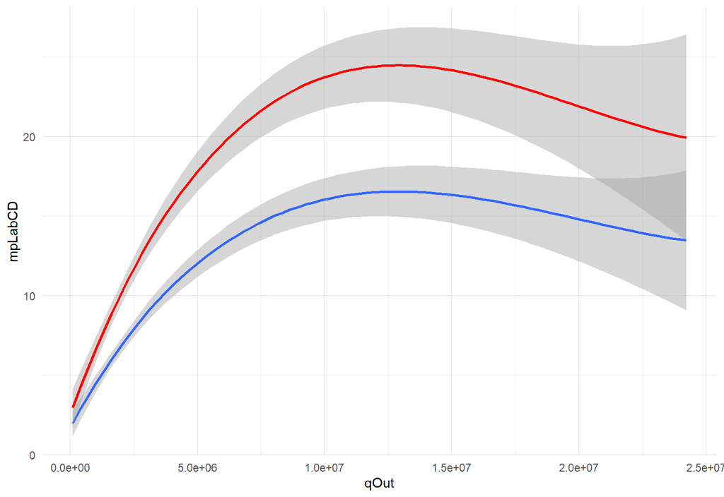

```r
dat %>%
  ggplot() +
  geom_smooth(aes(qOut, mpLabCD), se = T, span = 1) +
  geom_smooth(aes(qOut, apLab), se = T, span = 1, color = "red") +
  theme_minimal()
```